# BIOL 6220 Final Project - Cambria Miller

### Species Distribution Model - GLM

```r
# Build a model using training data
glm_model <- glm(pa ~ ., data = training, family = binomial())
```

```r
# Predict habitat suitability using the GLM model
glm_predict <- predict(bioclim_data_SR, glm_model, type = "response")
```

```
## |---------|---------|---------|---------|=========================================
```

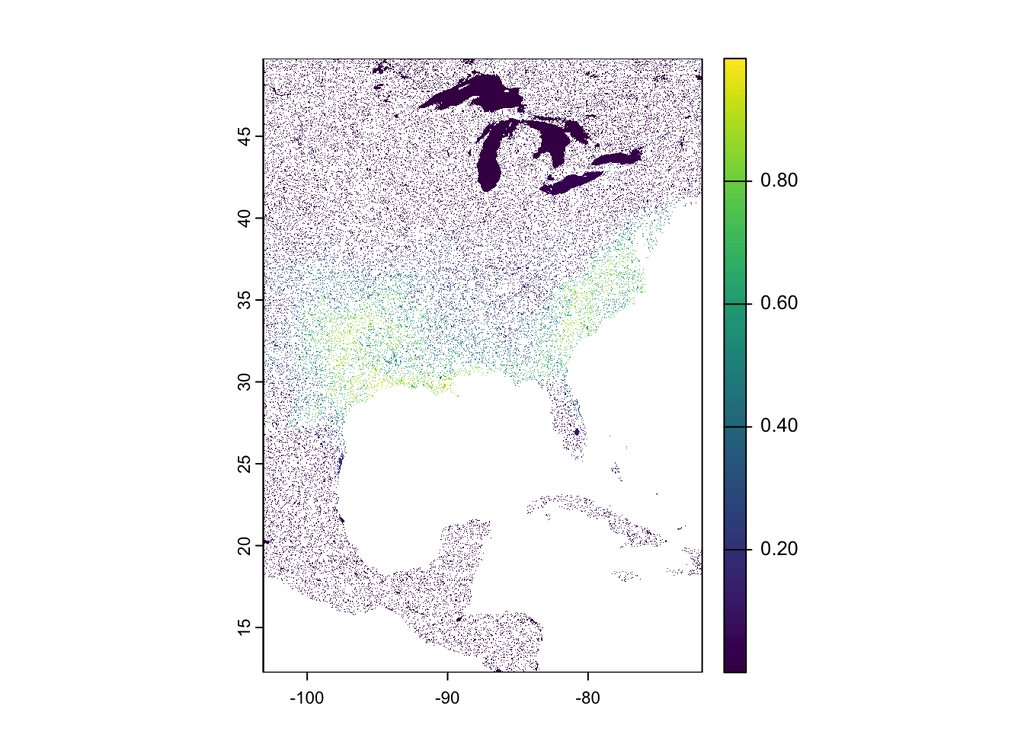

```r
# Print GLM prediction
plot(glm_predict)
```

```r
# Evaluate the GLM model using testing data
glm_eval <- pa_evaluate(p = testing[testing$pa == 1, ],
                        a = testing[testing$pa == 0, ],
                        model = glm_model,
                        type = "response")
```

```r
# Determine minimum threshold for "presence"
glm_threshold <- glm_eval@thresholds$max_spec_sens
```

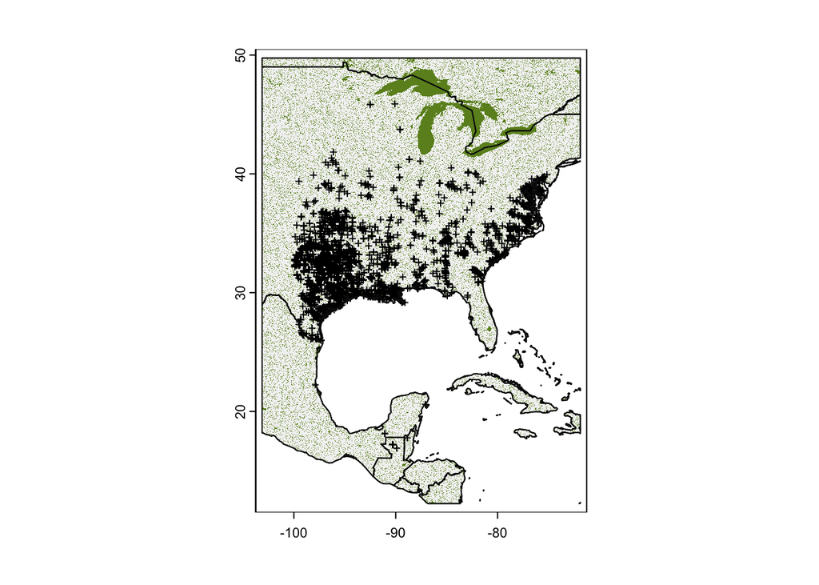

```r
# Plot base map
plot(my_map,
     axes = TRUE,
     col = "grey95")

# Only plot areas where probability of occurrence is greater than the threshold
plot(glm_predict > glm_threshold,
     add = TRUE,
     legend = FALSE,
     col = "olivedrab")

# And add those observations
points(x = obs_data$decimalLongitude,
       y = obs_data$decimalLatitude,
       col = "black",
       pch = "+",
       cex = 0.75)

# Redraw those country borders
plot(my_map, add = TRUE, border = "grey5")
```

```r
glm_predict > glm_threshold
```

```
## class       : SpatRaster
## dimensions  : 4500, 3750, 1  (nrow, ncol, nlyr)
## resolution  : 0.008333333, 0.008333333  (x, y)
## extent      : -103.125, -71.875, 12.25, 49.75  (xmin, xmax, ymin, ymax)
## coord. ref. : lon/lat WGS 84 (EPSG:4326)
## source(s)   : memory
## varname     : spat_52f1243ab7cf_21233
## name        :  lyr1
## min value   : FALSE
## max value   :  TRUE
```

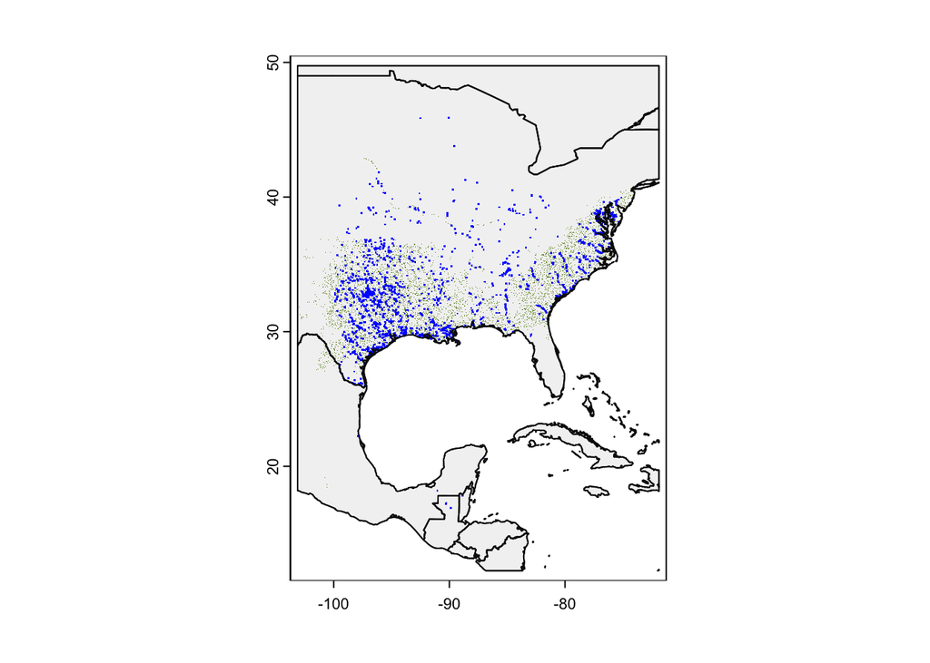

```r
# Plot base map
plot(my_map,
     axes = TRUE,
     col = "grey95")

# Only plot areas where probability of occurrence is greater than the threshold
plot(glm_predict > glm_threshold,
     add = TRUE,
     legend = FALSE,
     col = c(NA, "olivedrab")) # <-- Update the values HERE

# And add those observations
points(x = obs_data$decimalLongitude,
       y = obs_data$decimalLatitude,
       #col = alpha("blue",0.5),
       col = "blue",
       pch = ".",
       cex = 0.0000000000001
       )

# Redraw those country borders
plot(my_map, add = TRUE, border = "grey5")
```

```r
# Save PDF
pdf("ICT_GLM_Pred.pdf")

# Plot base map
plot(my_map,
     axes = TRUE,
     col = "grey95")

# Only plot areas where probability of occurrence is greater than the threshold
plot(glm_predict > glm_threshold,
     add = TRUE,
     legend = FALSE,
     col = c(NA, "olivedrab")) # <-- Update the values HERE

# And add those observations
points(x = obs_data$decimalLongitude,
       y = obs_data$decimalLatitude,
       #col = alpha("blue",0.5),
       col = "blue",
       pch = ".",
       cex = 0.0000000000001
       )

# Redraw those country borders
plot(my_map, add = TRUE, border = "grey5")

dev.off()
```

```r
glm_model
```

```
##
## Call:  glm(formula = pa ~ ., family = binomial(), data = training)
##
## Coefficients:
##     (Intercept)  FW_hydro_avg_01  FW_hydro_avg_02  FW_hydro_avg_03
##       9.805e+00       -6.040e-01        1.254e-01       -5.497e-01
## FW_hydro_avg_04  FW_hydro_avg_05  FW_hydro_avg_06  FW_hydro_avg_07
##      -8.862e-03       -6.871e-02       -4.930e-03               NA
## FW_hydro_avg_08  FW_hydro_avg_09  FW_hydro_avg_10  FW_hydro_avg_11
##       6.322e-03       -7.252e-03        7.059e-01        4.432e-02
## FW_hydro_avg_12  FW_hydro_avg_13  FW_hydro_avg_14  FW_hydro_avg_15
##      -1.898e-08        7.050e-07       -6.838e-07       -8.701e-02
## FW_hydro_avg_16  FW_hydro_avg_17  FW_hydro_avg_18  FW_hydro_avg_19
##      -2.159e-07        2.810e-07               NA               NA
##
## Degrees of Freedom: 10903 Total (i.e. Null);  10887 Residual
##   (4713 observations deleted due to missingness)
## Null Deviance:       13350
## Residual Deviance: 6073  AIC: 6107
```

```r
geotiffs <- list.files(path = "data/climate/wc2.1_2.5m/", pattern = ".tif")

dir.create("data/ascii_files")

for (i in geotiffs) {
  f <- raster::raster(paste0("data/climate/wc2.1_2.5m/",i))
  r <- raster::readAll(f)
  r <- raster::crop(r, sample_extent)
  writeRaster(r, paste0("data/ascii_files/",i,".asc"), format = "ascii", overwrite=TRUE)
}
```

```r
# Prepare occurrence data for MaxEnt model
GBIF4MIAmaxent <- as.data.frame(cbind(Ictalurus.furcatus_GBIF$decimalLongitude, Ictalurus.furcatus_GBIF$decimalLatitude))

GBIF4MIAmaxent <- GBIF4MIAmaxent %>%
  add_column(Occurrence = "presence")

colnames(GBIF4MIAmaxent) <- c("POINT_X", "POINT_Y", "Occurrence")

GBIF4MIAmaxent <- GBIF4MIAmaxent %>%
  dplyr::select(Occurrence, everything())

# Write occurrence data for MaxEnt
write.csv(GBIF4MIAmaxent, "data/GBIF4MIAmaxent.csv", row.names = FALSE)
```

```r
# Prepare and fit the MaxEnt model
GBIFPO <- readData(
  occurrence = "data/GBIF4MIAmaxent.csv",
  contEV = "data/ascii_files/",
  maxbkg=20000,
  PA = FALSE
)
```

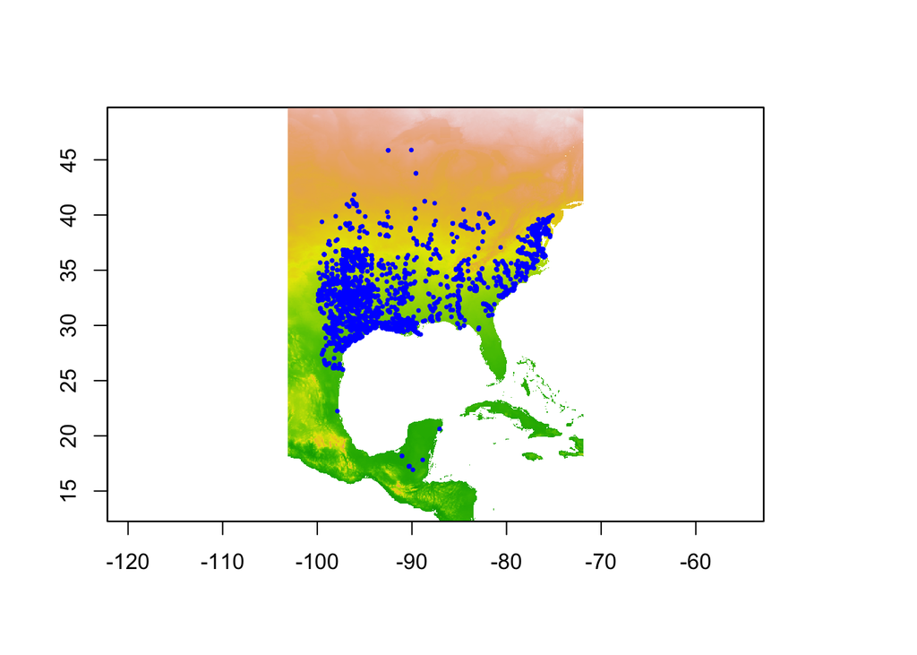

```r
# Plot environmental variables with occurrence points
EV1 <- raster::raster(list.files("data/ascii_files/", full.names=TRUE)[1])

PO <- read.csv("data/GBIF4MIAmaxent.csv")

plot(EV1, legend=FALSE)
points(PO$POINT_X, PO$POINT_Y, pch = 20, cex = 0.5, col = "blue")
```

```r
str(GBIFPO)
```

```
## 'data.frame':    21809 obs. of  20 variables:
##  $ RV                   : num  1 1 1 1 1 1 1 1 1 1 ...
##  $ wc2.1.2.5m.bio.1.tif : num  15.7 17.8 22.5 20.8 15.9 ...
##  $ wc2.1.2.5m.bio.10.tif: num  26.4 26.6 28.9 28.1 26.2 ...
##  $ wc2.1.2.5m.bio.11.tif: num  4.21 8.52 15.06 12.81 4.99 ...
##  $ wc2.1.2.5m.bio.12.tif: num  1063 1422 803 1270 1189 ...
##  $ wc2.1.2.5m.bio.13.tif: num  139 152 145 152 138 113 145 163 118 115 ...
##  $ wc2.1.2.5m.bio.14.tif: num  42 85 30 72 64 35 53 81 48 47 ...
##  $ wc2.1.2.5m.bio.15.tif: num  31.9 21.3 48.2 24.3 20.3 ...
##  $ wc2.1.2.5m.bio.16.tif: num  347 424 321 384 365 274 362 421 282 291 ...
##  $ wc2.1.2.5m.bio.17.tif: num  162 263 124 226 255 116 192 277 167 152 ...
##  $ wc2.1.2.5m.bio.18.tif: num  248 291 225 371 261 226 253 302 184 222 ...
##  $ wc2.1.2.5m.bio.19.tif: num  162 412 134 269 255 117 192 394 167 152 ...
##  $ wc2.1.2.5m.bio.2.tif : num  12.75 12.61 9.5 9.61 13.44 ...
##  $ wc2.1.2.5m.bio.3.tif : num  34.1 39.7 38.1 36.7 36.7 ...
##  $ wc2.1.2.5m.bio.4.tif : num  896 735 566 623 855 ...
##  $ wc2.1.2.5m.bio.5.tif : num  33.8 33.1 33.7 33.1 34 ...
##  $ wc2.1.2.5m.bio.6.tif : num  -3.58 1.41 8.79 6.88 -2.64 ...
##  $ wc2.1.2.5m.bio.7.tif : num  37.4 31.7 24.9 26.2 36.6 ...
##  $ wc2.1.2.5m.bio.8.tif : num  20.1 17.7 27.1 26.8 15.6 ...
##  $ wc2.1.2.5m.bio.9.tif : num  4.21 23.16 16.25 17.07 4.99 ...
```

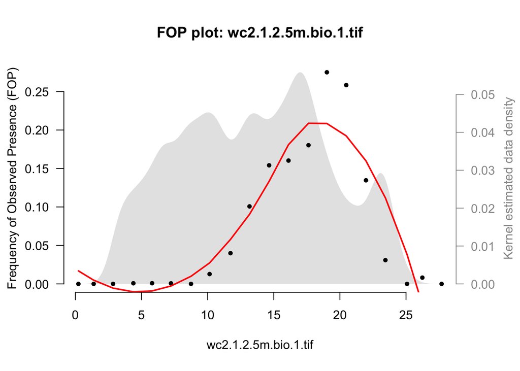

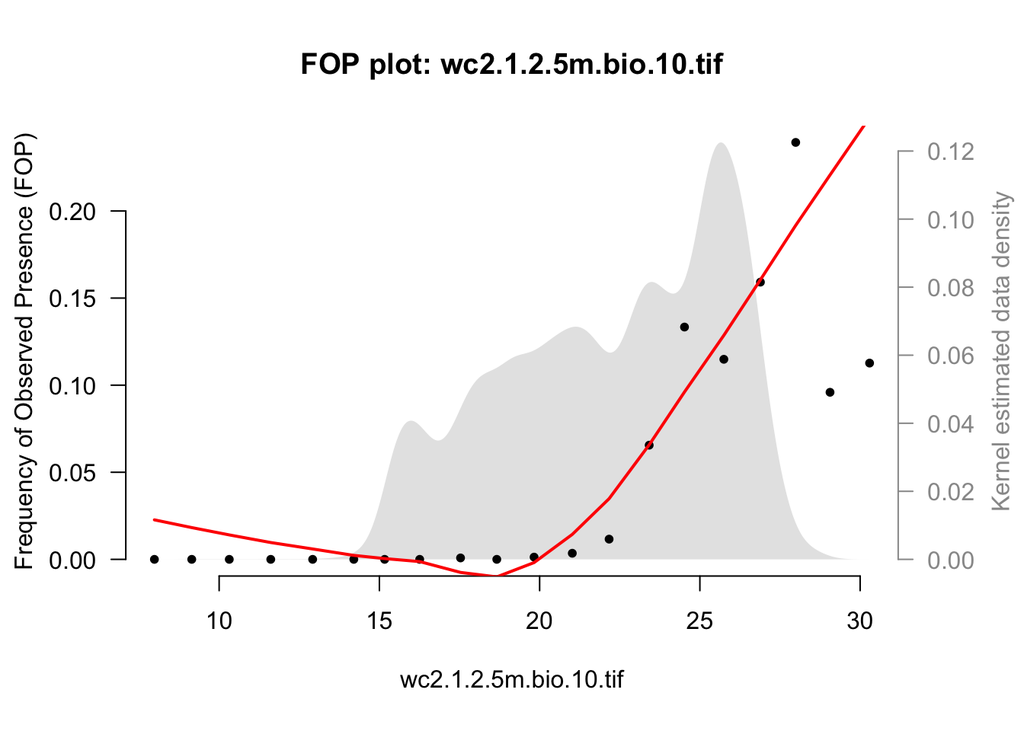

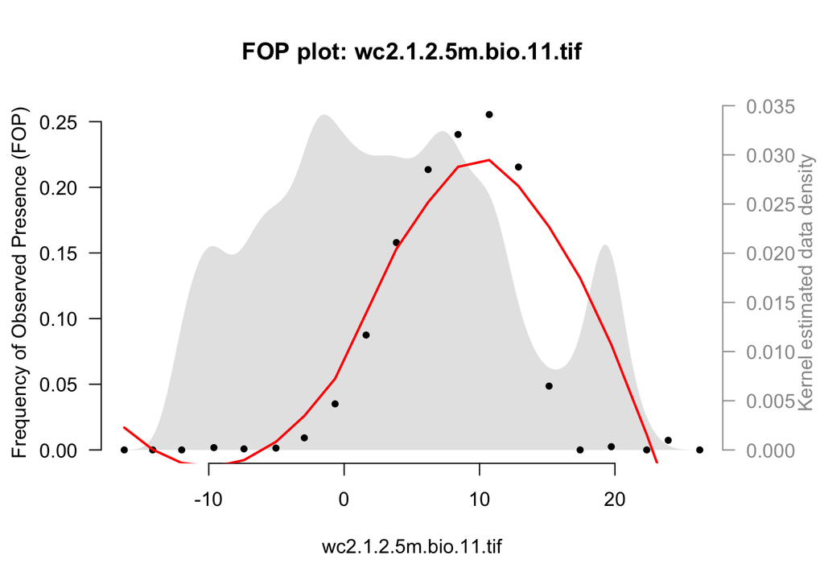

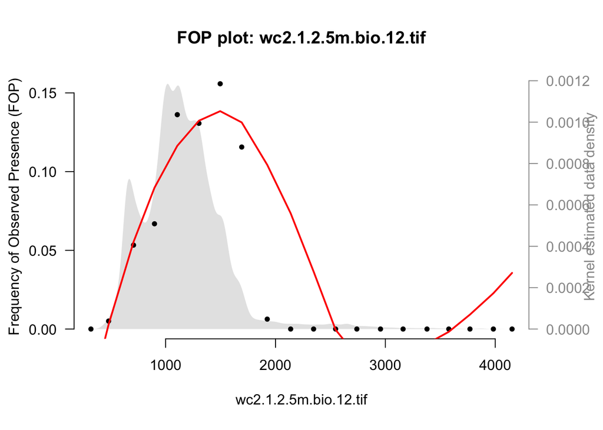

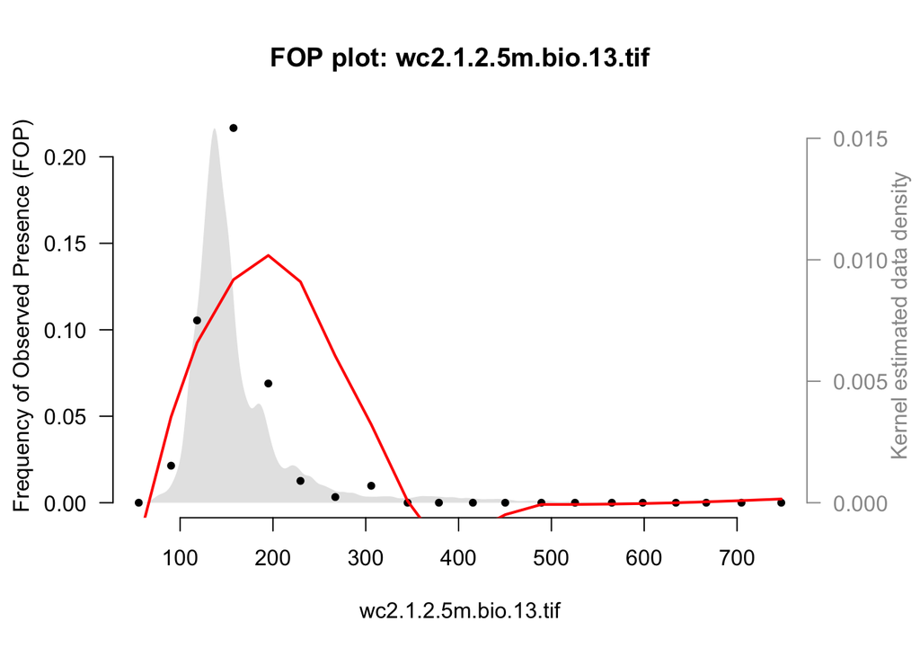

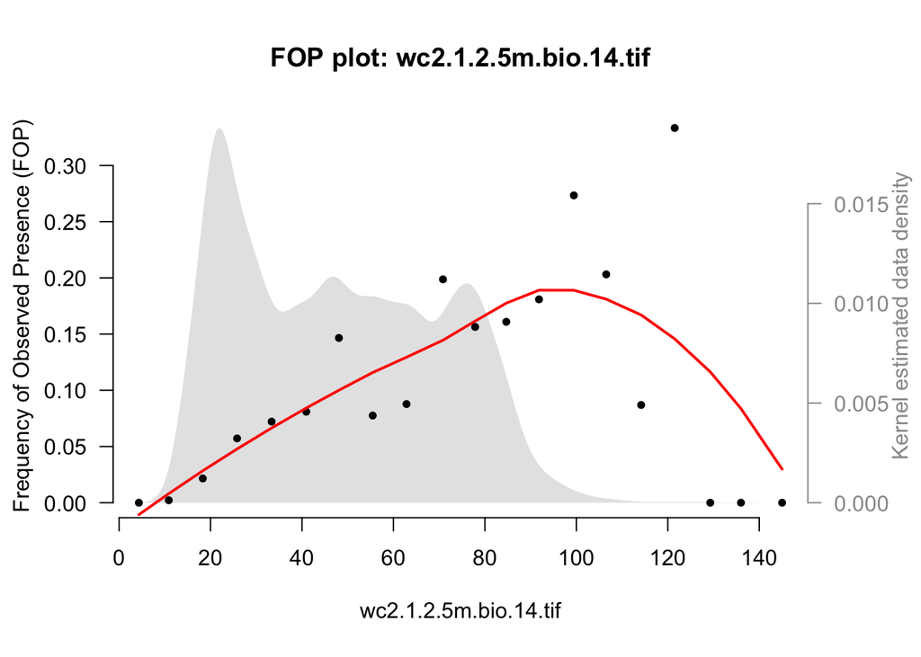

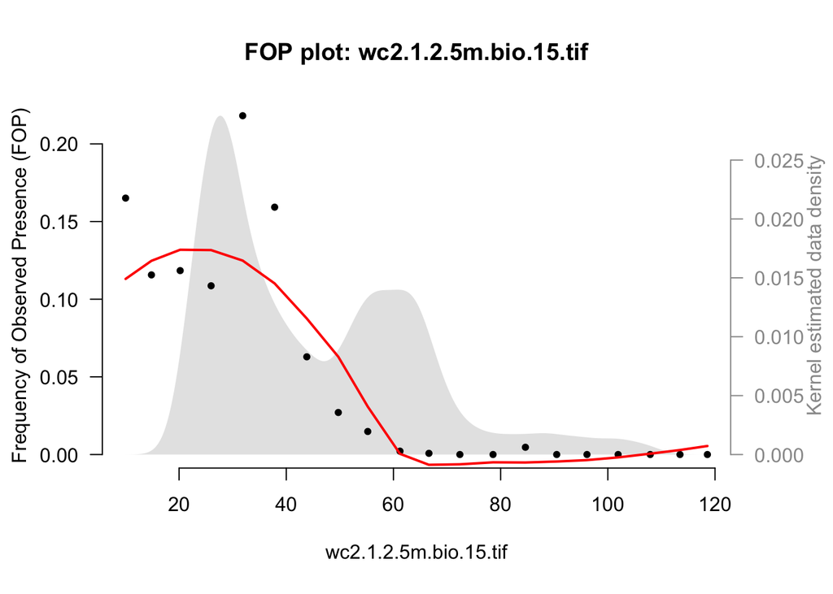

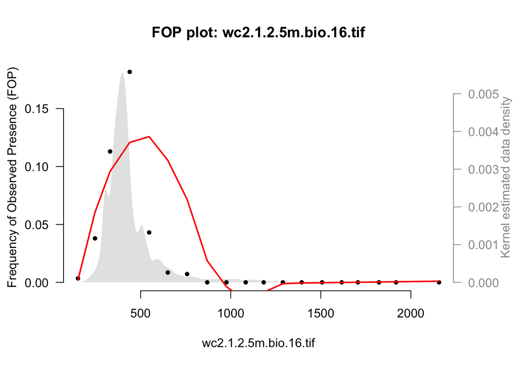

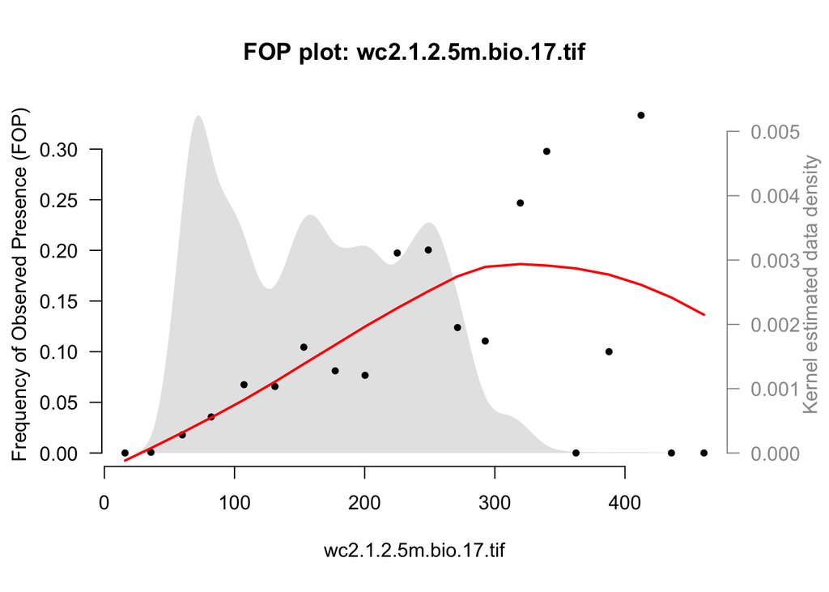

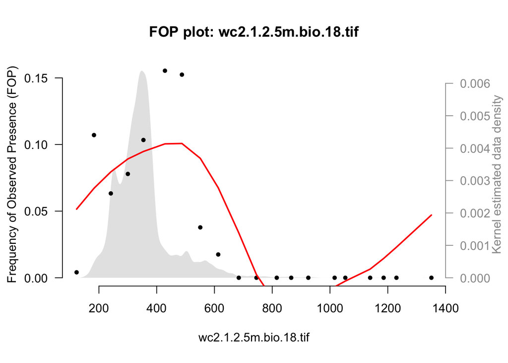

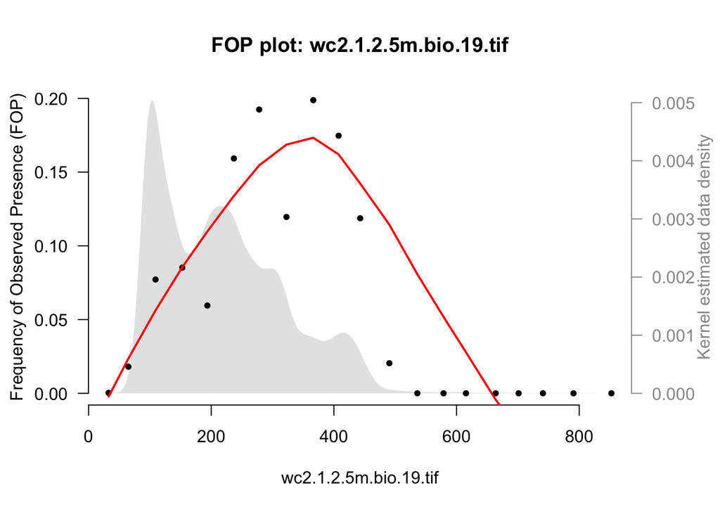

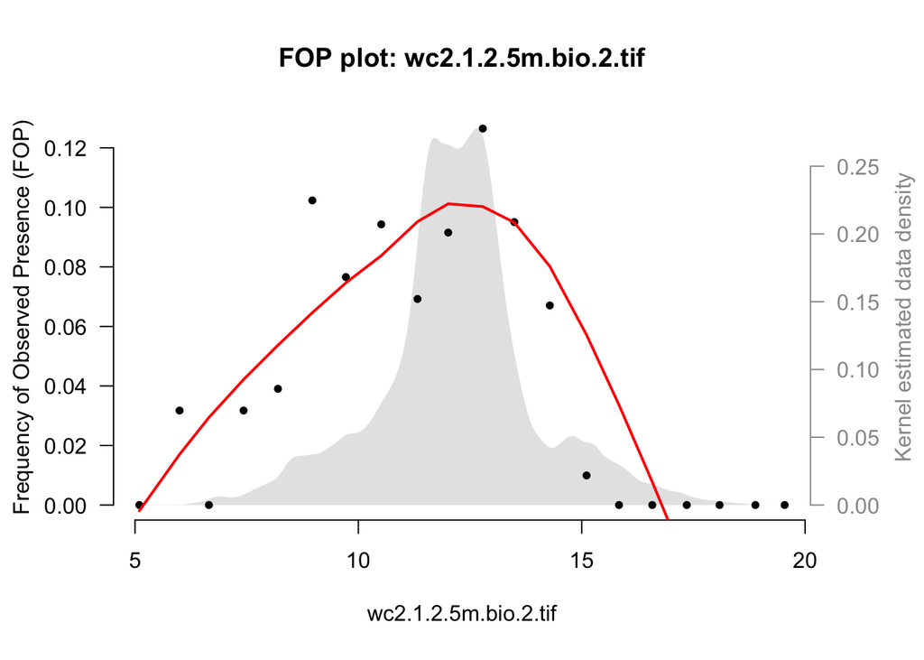

[7 more figures not shown]

```r
for (n in list.files(path = "data/climate/wc2.1_2.5m/", pattern = ".tif")) {
  plotFOP(GBIFPO, stringr::str_replace_all(n, pattern = "_", replacement = "."), span = 0.75, intervals = 20)
}
```

### Species Distribution Model - Logistic Regression

```r
# Prepare and fit the logistic regression
GBIFDVs.LR <- deriveVars(GBIFPO, algorithm = "LR")
```

```r
GBIFDVselect.LR <- selectDVforEV(GBIFDVs.LR$dvdata, alpha = 0.001,
                                 algorithm = "LR")
```

[output not shown]

```r
GBIFEVselect.LR <- selectEV(GBIFDVselect.LR$dvdata, alpha = 0.001,
                            algorithm = "LR")
```

```r
# Build and project the Logistic Regression model
EVfiles <- c(list.files("data/ascii_files/", pattern = ".asc", full.names=TRUE))
EVstack <- raster::stack(EVfiles)
GBIFPreds.LR <- projectModel(model = GBIFEVselect.LR$selectedmodel,
                               transformations = GBIFDVs.LR$transformations,
                               data = EVstack)
```

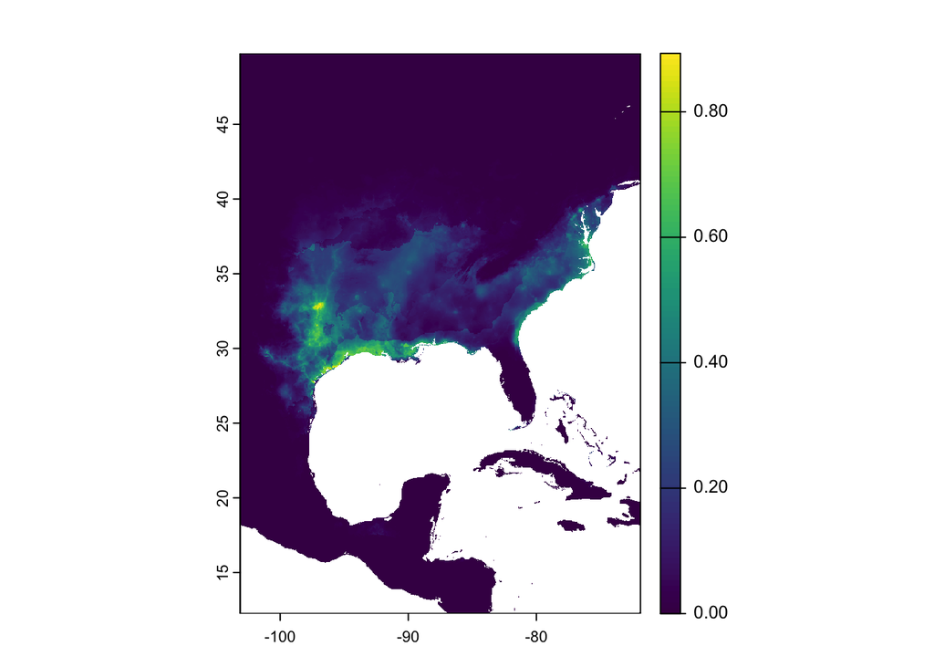

```r
# Plot Logistic Regression predictions
pdf("GBIF_MIAMAXENT_Pred_LR.pdf")
plot(GBIFPreds.LR$output)
dev.off()
```

```r
plot(GBIFPreds.LR$output)
```

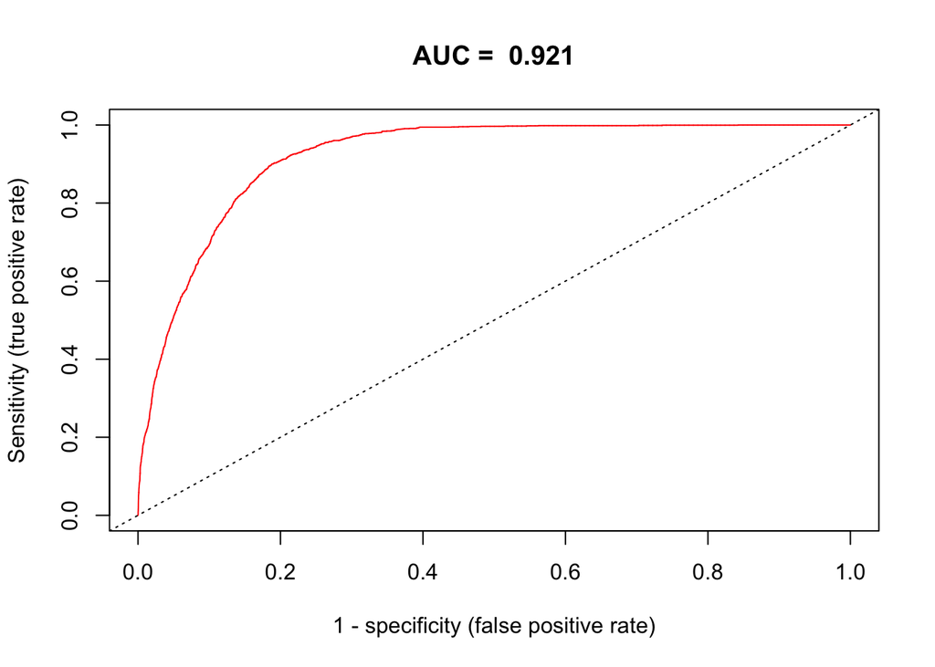

```
## [1] 0.9210379
```

```r
# Test AUC for Logistic Regression model
testAUC(GBIFEVselect.LR$selectedmodel, GBIFDVs.LR$transformations, GBIFPO)
```

```r
sf_use_s2(FALSE)

world <- ne_countries(scale = "medium", returnclass = "sf")

easternUS <- st_crop(world, c(xmin=-103.125, xmax=-71.875, ymin=12.25, ymax=49.75))
```

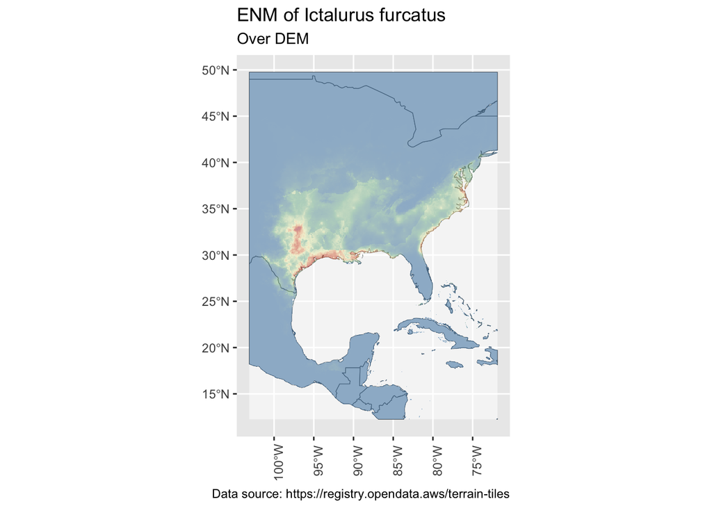

```r
ggplot(data=easternUS) +
  geom_sf() +
  geom_spatraster(data = GBIFPreds.LR$output, alpha = 0.5) +
  scale_fill_whitebox_c(palette = "muted", na.value = "transparent", guide = 'none') +
  labs(title = 'ENM of Ictalurus furcatus',
       subtitle = 'Over DEM',
       caption = 'Data source: https://registry.opendata.aws/terrain-tiles') +
  theme(axis.text.x = element_text(angle=90))
```

```r
sf_use_s2(TRUE)
```

### References

- Global Biodiversity Information Facility (GBIF). (2024). Data retrieved from: https://www.gbif.org/
- Environmental Data: WorldClim, http://worldclim.org/

```r
# Layer citations
print(layer_citations(layercodes))
```

```
## [1] "Domisch S, Amutelli G, Jetz W (2015). \"Near-global freshwater-specific environmental variables for biodiversity analyses in 1 km resolution.\"\n_Scientific Data_. doi:10.1038/sdata.2015.73\n<https://doi.org/10.1038/sdata.2015.73>."
```

- R Packages: dplyr: Wickham, H., François, R., Henry, L., & Müller, K. (2023). dplyr: A Grammar of Data Manipulation. R package version 1.1.3. https://CRAN.R-project.org/package=dplyr elevatr: Chandler, R. E., & Frost, T. (2019). elevatr: Accessing Elevation Data from various sources. R package version 0.1.0. https://CRAN.R-project.org/package=elevatr geodata: Köhler, P., & Baddeley, A. (2020). geodata: Tools for Accessing and Visualizing Geo-Referenced Data. R package version 1.0.1. https://CRAN.R-project.org/package=geodata ggmap: Kahle, D., & Wickham, H. (2013). ggmap: Spatial Visualization with ggplot2. R package version 3.0.0. https://CRAN.R-project.org/package=ggmap ggplot2: Wickham, H. (2016). ggplot2: Elegant Graphics for Data Analysis. Springer-Verlag New York. https://ggplot2.tidyverse.org ggsflabel: Heuvelink, G. B. M., & Seifert, T. (2021). ggsflabel: Geospatial ggplot2 Labels for sf Objects. R package version 0.2.0. https://CRAN.R-project.org/package=ggsflabel ggspatial: Brunsdon, C., & Comber, A. (2020). ggspatial: Add Spatial Data to ggplot2 Plots. R package version 1.1.4. https://CRAN.R-project.org/package=ggspatial predicts: Hill, S. L. L., et al. (2019). predicts: Predicting Species Distributions from Global Data. R package version 0.3.0. https://CRAN.R-project.org/package=predicts raster: Hijmans, R. J., & van Etten, J. (2022). raster: Geographic Data Analysis and Modeling. R package version 3.5-15. https://CRAN.R-project.org/package=raster rnaturalearth: South, A. (2017). rnaturalearth: World Map Data for R. R package version 0.1.0. https://CRAN.R-project.org/package=rnaturalearth rnaturalearthdata: South, A. (2021). rnaturalearthdata: Natural Earth Data. R package version 0.1.0. https://CRAN.R-project.org/package=rnaturalearthdata rgbif: Beck, J., et al. (2020). rgbif: Interface to the Global Biodiversity Information Facility API. R package version 3.2.1. https://CRAN.R-project.org/package=rgbif sf: Pebesma, E. (2018). sf: Simple Features for R. R package version 0.9-8. https://CRAN.R-project.org/package=sf stars: Pebesma, E. (2021). stars: Spatiotemporal Arrays. R package version 0.5-3. https://CRAN.R-project.org/package=stars sdmpredictors: Barbet-Massin, M., et al. (2018). sdmpredictors: A Tool to Model Species Distribution Using Environmental Data. R package version 0.2.8. https://CRAN.R-project.org/package=sdmpredictors stringr: Wickham, H. (2023). stringr: Simple, Consistent Wrappers for Common String Operations. R package version 1.5.0. https://CRAN.R-project.org/package=stringr terra: Pebesma, E., & Bivand, R. (2020). terra: Spatial Data Analysis in R. R package version 1.2-0. https://CRAN.R-project.org/package=terra tigris: Bivand, R., & Keitt, T. (2021). tigris: Provides Access to TIGER/Line Shapefiles. R package version 1.0-1. https://CRAN.R-project.org/package=tigris tidyverse: Wickham, H., et al. (2019). tidyverse: Easily Install and Load the ‘Tidyverse’. R package version 1.3.1. https://CRAN.R-project.org/package=tidyverse tidyterra: Bivand, R., & Pebesma, E. (2020). tidyterra: Data Transformation and Visualization for Raster Objects. R package version 0.2.0. https://CRAN.R-project.org/package=tidyterra tibble: Wickham, H. (2023). tibble: Simple Data Frames. R package version 3.2.0. https://CRAN.R-project.org/package=tibble